# L01 Visualization

Data Science 1 with R (STAT 301-1)

Author

Allison Kane

**Github Repo Link**

https://github.com/stat301-1-2023-fall/L01-visualization-akane2460.git

## Load packages

```r
# Loading package(s)

library(tidyverse)
```

## Datasets

This lab utilizes the `mpg` and `diamonds` datasets. Both come with `ggplot2`.

```r
# read in data
tinder_data <- read_csv("data/tinder_data.csv")
```

## Exercises

### Exercise 1

There are 3 particularly important components to our template for building a graphic with `ggplot2`. They are `<DATA>`, `<GEOM_FUNCTION>`, and `<MAPPINGS>`. The importance of `<DATA>` is obvious. `<GEOM_FUNCTION>` is referring to the selection of a **geom**. `<MAPPINGS>`, specifically `aes(<MAPPINGS>)`, is referring to the process of defining **aesthetic mappings**.

- What is a **geom**?
- What is an **aesthetic mapping**?

**Solution**

What is a geom? A geom is the object a plot uses to represent data. What is an aesthetic mapping? An aesthetic maapping defines how variables in the dataset are mapped to visual properties.

### Exercise 2

Construct a scatterplot of `hwy` versus `cty` using the `mpg` dataset. What is the problem with this plot? How could you improve it?

**Solution**

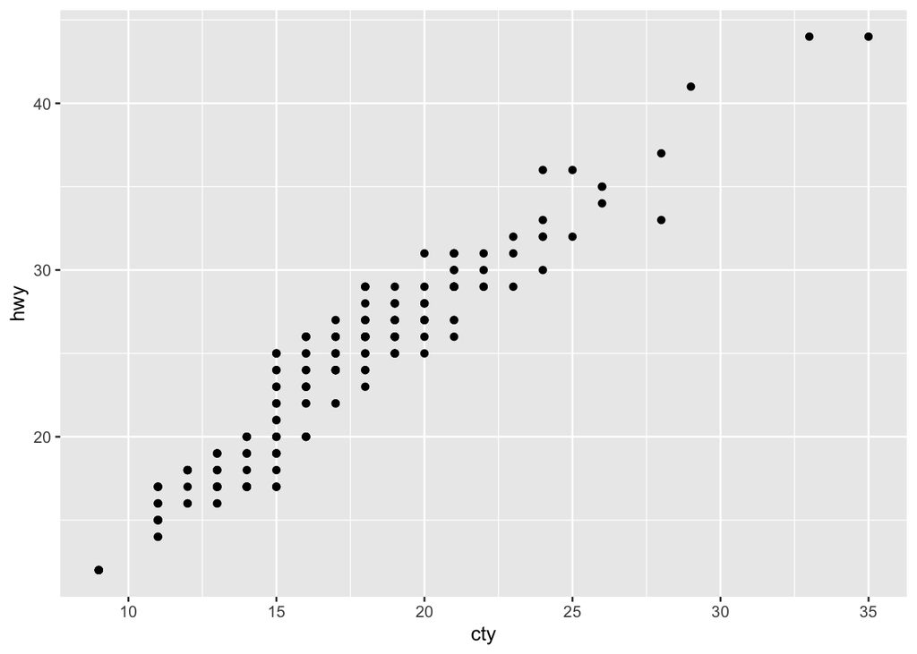

```r
# original
ggplot(data = mpg, aes(x = cty, y = hwy)) +
  geom_point()
```

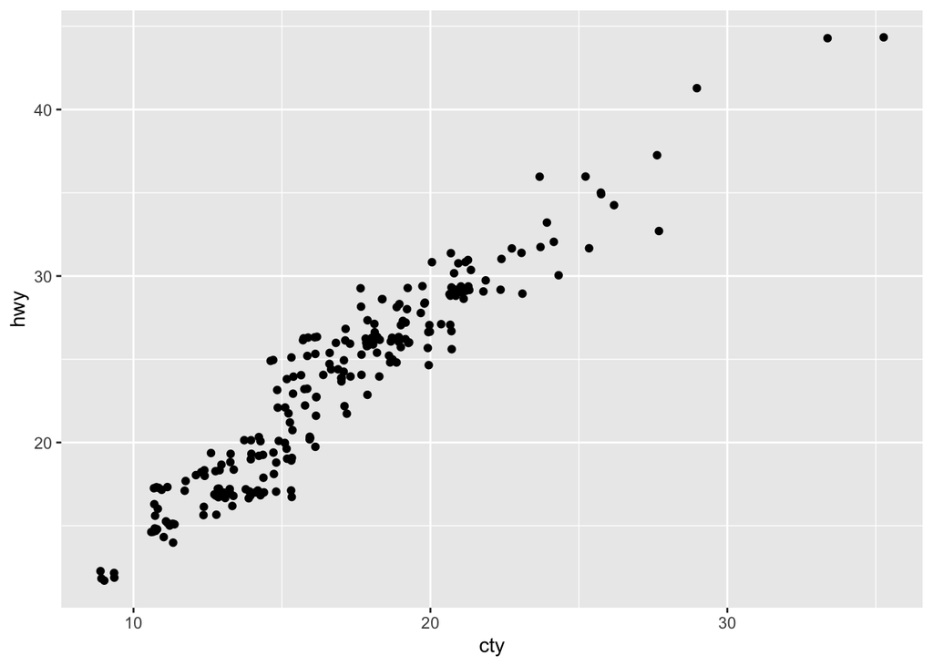

```r
# jittered graph
ggplot(data = mpg, aes(x = cty, y = hwy)) +
  geom_jitter()
```

OVERPLOTTING is the issue here, it can be fixed using geom_jitter

### Exercise 3

Construct a scatterplot of `hwy` versus `cty`. Set the color of the points to `drv`.

Now construct a scatterplot of `hwy` versus `cty`. Set the color of the points to your favorite color (try typing `colors()` in the console) and `facet` by `drv`. Read `?facet_wrap` and adjust the `ncol` and `scales` as necessary.

**Solution**

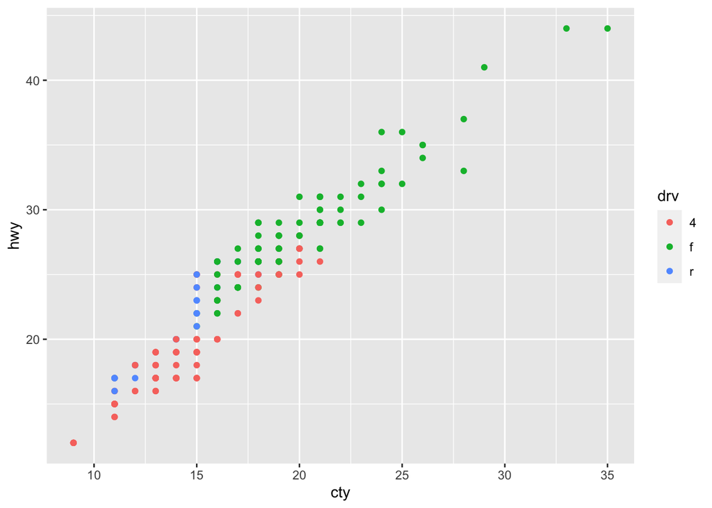

```r
# build plot with facet_wrap based on "drv"
ggplot(data = mpg, aes(x = cty, y = hwy, color = drv)) +
  geom_point()
```

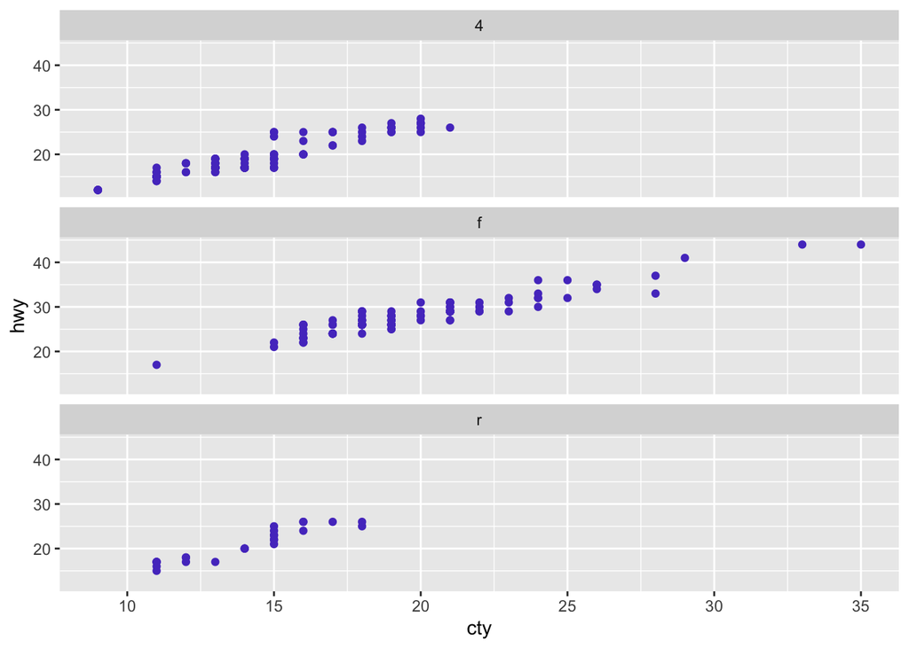

```r
# build plot with facet_wrap based on "drv"
ggplot(data = mpg, aes(x = cty, y = hwy)) +
  geom_point(color = "#573ec7") +
  facet_wrap("drv", ncol = 1, scales = "fixed")
```

What are the advantages to using faceting instead of the color aesthetic? What are the disadvantages? How might the balance change if you had a larger dataset?

**Solution**

It is easier to discern the overall patterns of each. However it is difficult to discern how these overall trends relate to each other. If there was a larger dataset, there might be more groups that might make it difficult to visualize trends across so many individual plots.

### Exercise 4

Construct a scatterplot of `hwy` vs `cty`. Next, map a third numerical variable to `color`, then `size`, then `shape`.

**Solution**

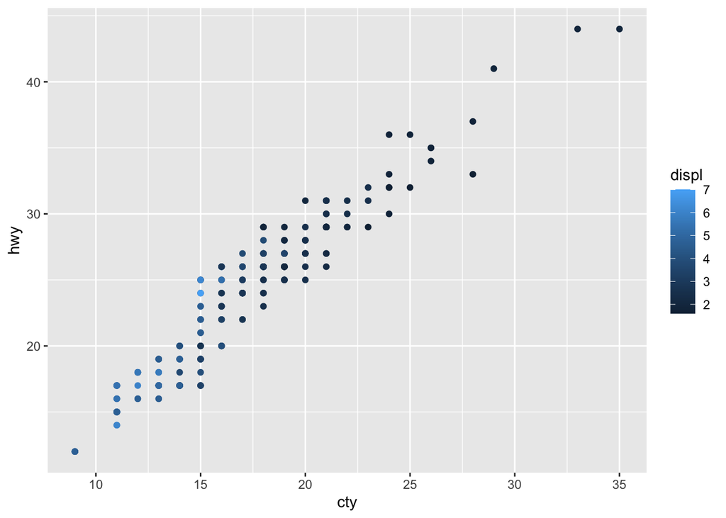

```r
# mapping engine displacement to color
ggplot(data = mpg, aes(x = cty, y = hwy, color = displ)) +
  geom_point()
```

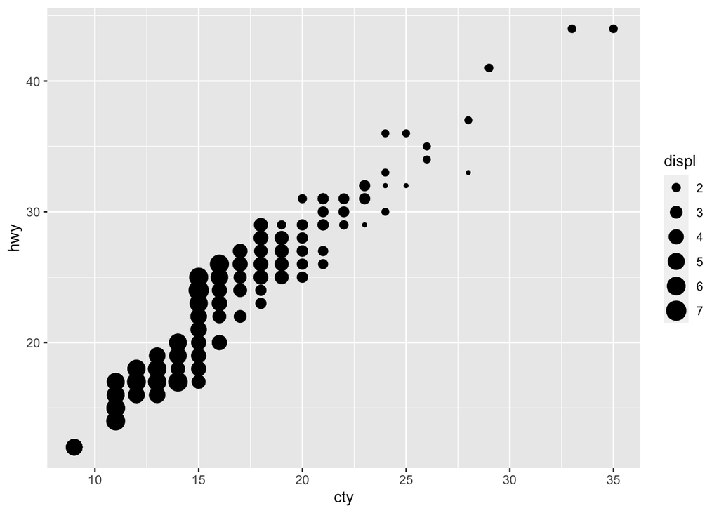

```r
# mapping engine displacement to size
ggplot(data = mpg, aes(x = cty, y = hwy, size = displ)) +
  geom_point()
```

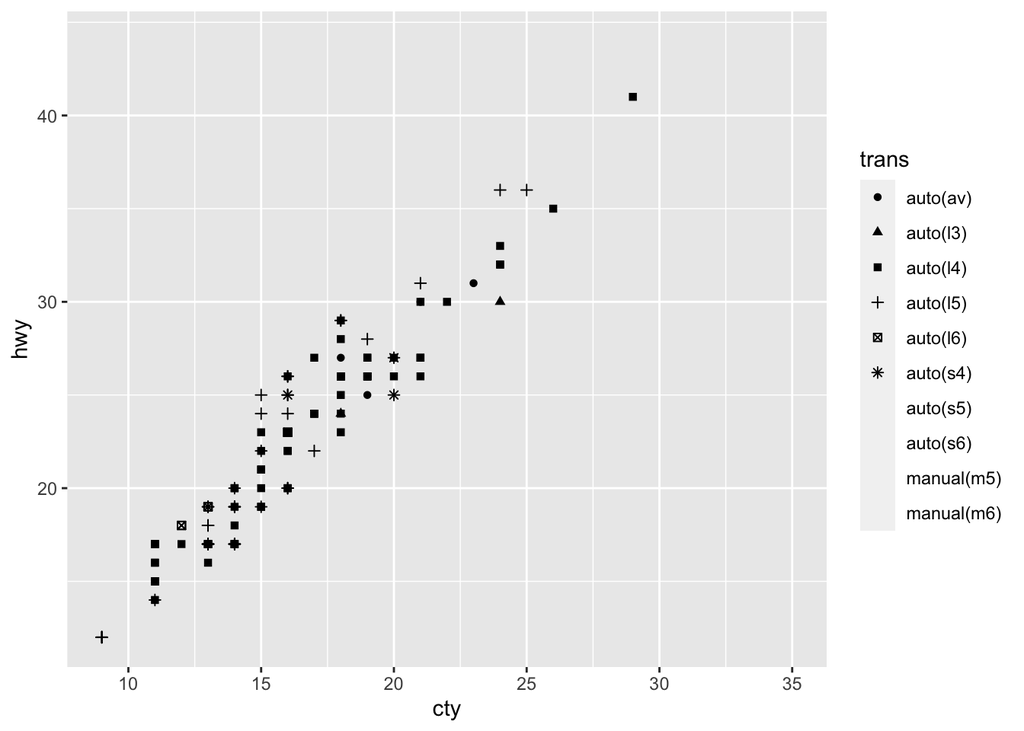

```r
# mapping type of transmission to shape
ggplot(data = mpg, aes(x = cty, y = hwy, shape = trans)) +
  geom_point()
```

How do the aesthetics behave differently for categorical versus numerical variables? In other words, which variable types (numeric/categorical) are appropriate to match to which aesthetics (size/shape/color)?

**Solution**

Different aesthetics are well-suited to different types of variables. Categorical variables align better with aesthetics like shape and color. Numeric variables are more appropriate to match aesthetics like size.

### Exercise 5

Construct a histogram of the `carat` variable in the `diamonds` dataset. Adjust the `bins` to an appropriate value. Add a `title`, remove the axis label that says `count`, and add a `caption`: “Source: ggplot2 package”.

**Solution**

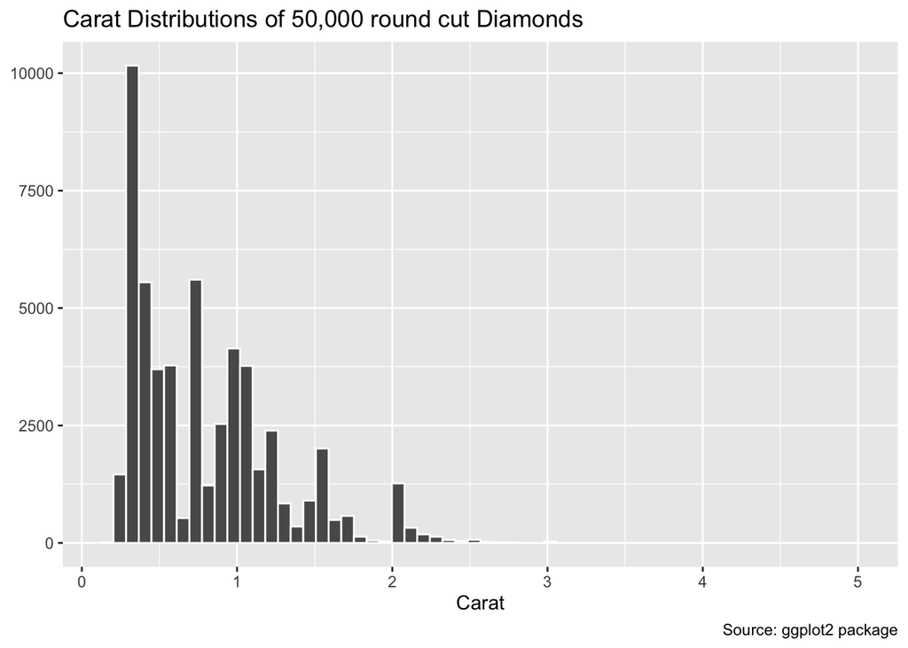

```r
# histogram
diamonds |>
  ggplot(aes(carat)) +
    geom_histogram(bins = 60, color = "white") +
    labs(
      title = "Carat Distributions of 50,000 round cut Diamonds",
      y = NULL,
      x = "Carat",
      caption = "Source: ggplot2 package"
    )
```

### Exercise 6

Construct 2 appropriate graphics to show the relationship between `carat` and `cut`.

**Solution**

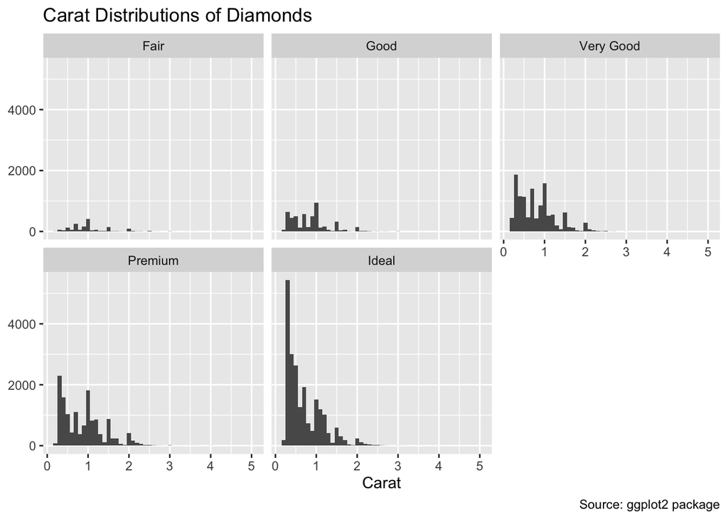

```r
# histogram
ggplot(data = diamonds, aes(x = carat)) +
  geom_histogram(stat = "bin", binwidth = .1) +
  facet_wrap(~ cut) +
  labs(
    title = "Carat Distributions of Diamonds",
    y = NULL,
    x = "Carat",
    caption = "Source: ggplot2 package"
  )
```

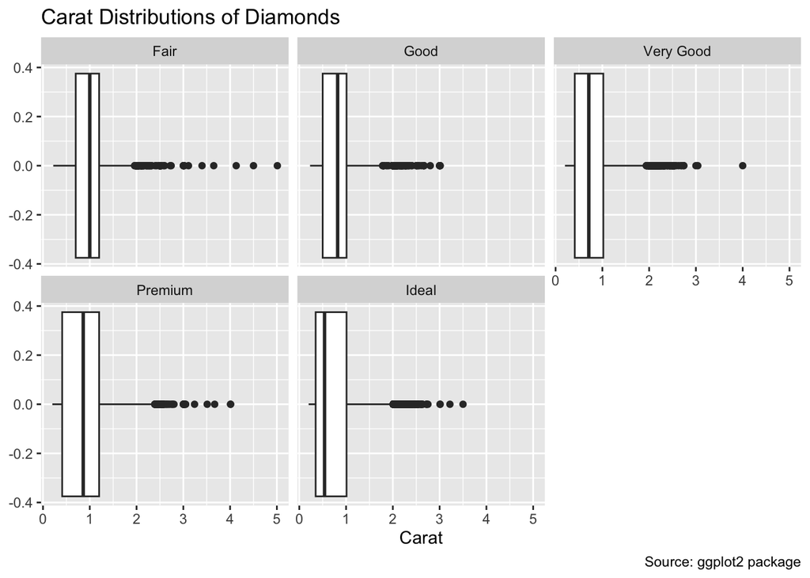

```r
# boxplot
ggplot(data = diamonds, aes(x = carat)) +
  geom_boxplot() +
  facet_wrap(~ cut) +
  labs(
    title = "Carat Distributions of Diamonds",
    y = NULL,
    x = "Carat",
    caption = "Source: ggplot2 package"
  )
```

### Exercise 7

Construct a barplot of `cut`. Add in `aes(fill = carat > 0.7)`.

**Solution**

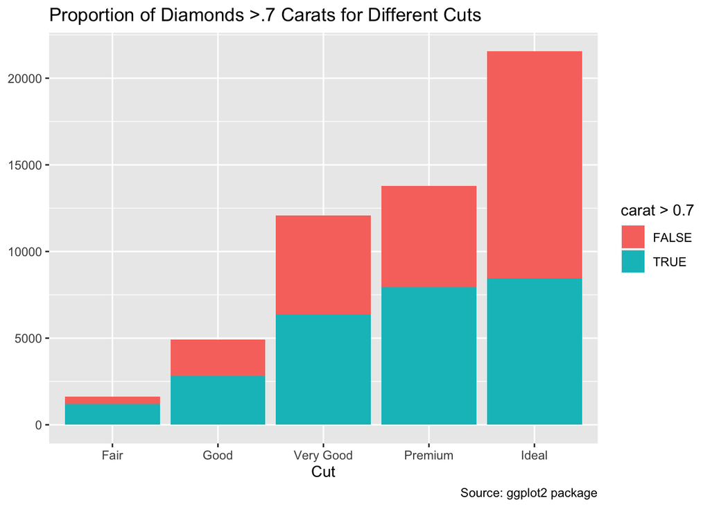

```r
# barplot
ggplot(data = diamonds, aes(x = cut)) +
  geom_bar(aes(fill = carat > .7)) +
  labs(
    title = "Proportion of Diamonds >.7 Carats for Different Cuts",
    y = NULL,
    x = "Cut",
    caption = "Source: ggplot2 package"
  )
```

### Exercise 8

When would you use `facet_grid()` versus `facet_wrap()`? When using `facet_grid()` it is suggested that you put the variable with more unique levels in the columns. Why do you think that this practice is suggested?

**Solution**

facet_grid might be more useful in comparing across unique levels in the columns because it is easier to visualize differences across the individual distributions with 2 discrete variables in its organized matrix of panels.

## Case Study

Congratulations, you just landed your first job as a data analyst for Tinder! The dataset is stored in the `data` folder called `tinder_data`. A codebook, `tinder_data_codebook.csv`, provides a description of each of the variable names. This has been read in for you at the top of the document. We will learn more about importing data later in the quarter.

**Your first assignment is to determine if there is a relationship between messages sent and messages received and how this differs based on user gender.** Your boss has asked for a one paragraph summary with graphics to support your conclusions. Your boss wants all graphics *saved* into a folder named “plots”. Hint: `ggsave()`.

Since this is your first project as a data analyst you have been provided some tips and considerations for getting started:

- When approaching a research question it is important to use univariate, bivariate, and multivariate analysis (depending on the problem) to get a better understanding of your data and also identify any potential problems.
- How might the distribution of your variables impact your conclusions? Outliers? Weird values? Imbalanced classes?
- How might `coord_fixed()` and `geom_abline()` improve a graphic?
- Feel free to be creative! It is your job to answer this question and interpret conclusions in the most appropriate ways you see fit.

This dataset was provided by [Swipestats.io](https://www.swipestats.io/).

**Solution**

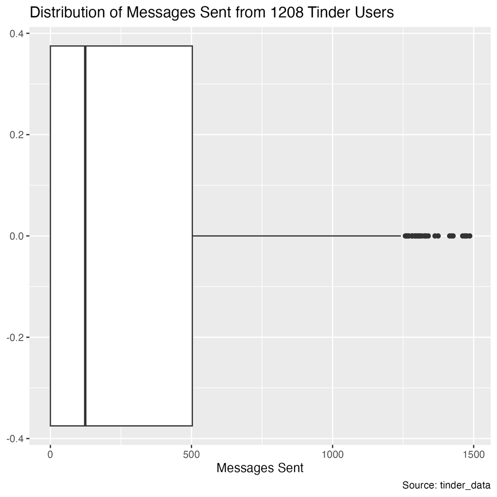

Messages Sent Boxplot

[figure not shown]

Messages Sent Density Plot

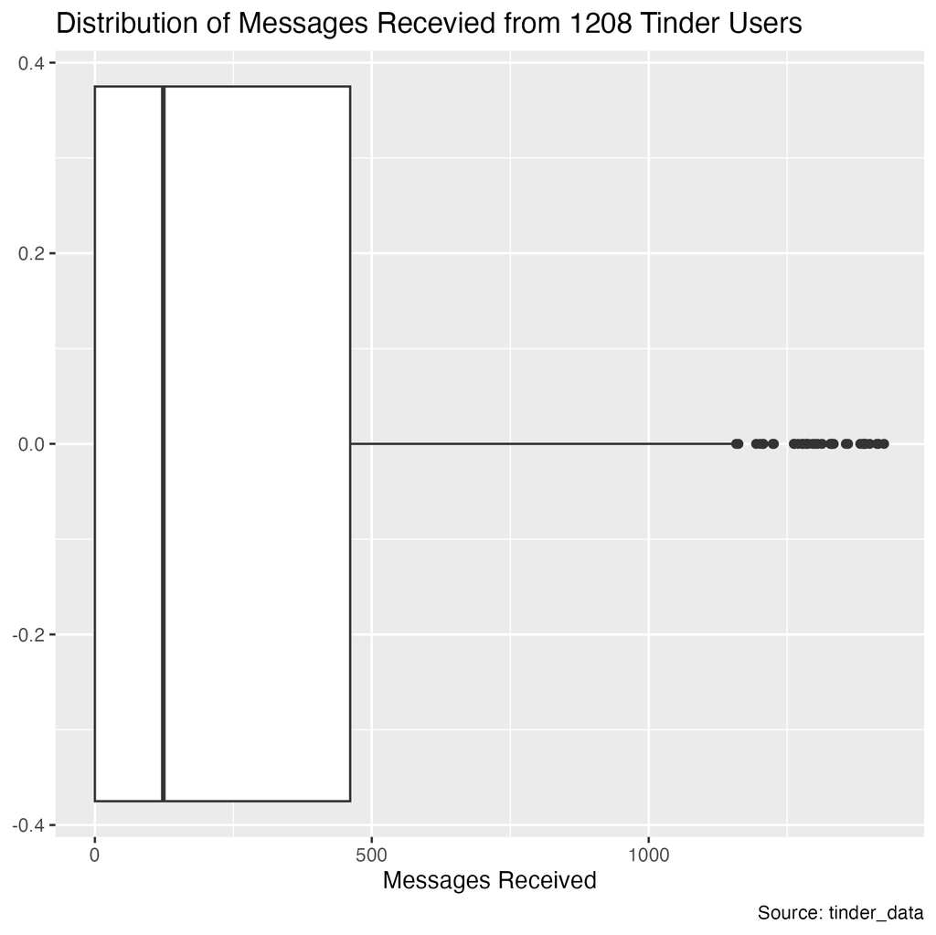

Messages Received Boxplot

[figure not shown]

Messages Received Density Plot

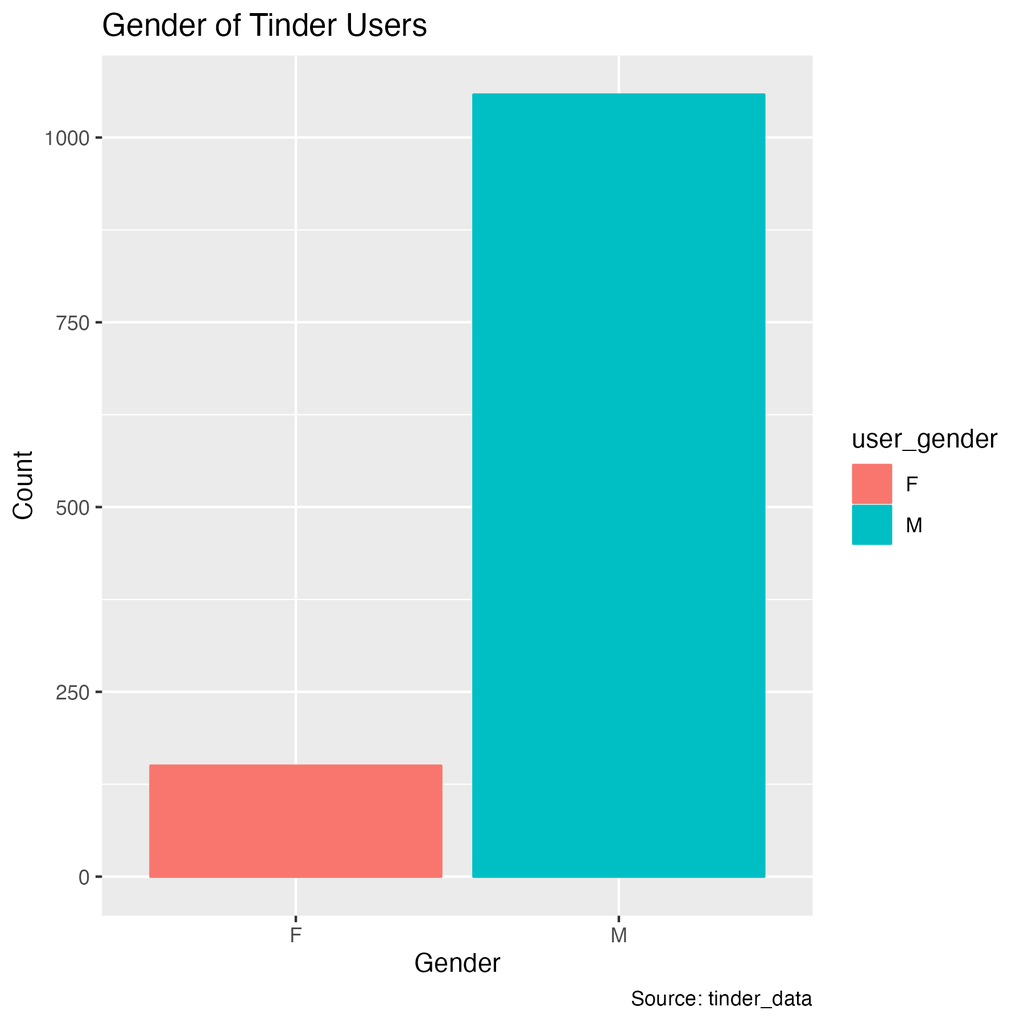

Gender Plot

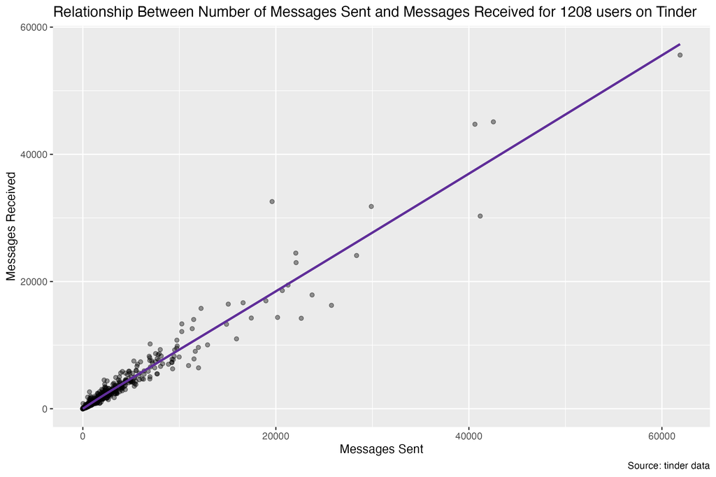

Relationship between Messages Sent and Messages Received

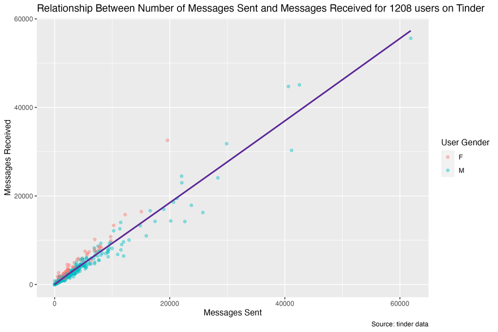

Relationship between Messages Sent and Messages Received by Gender

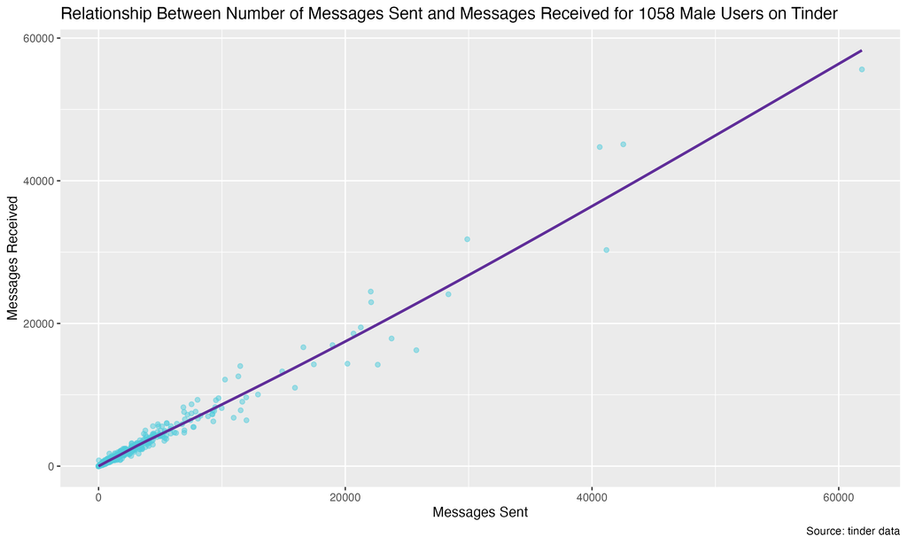

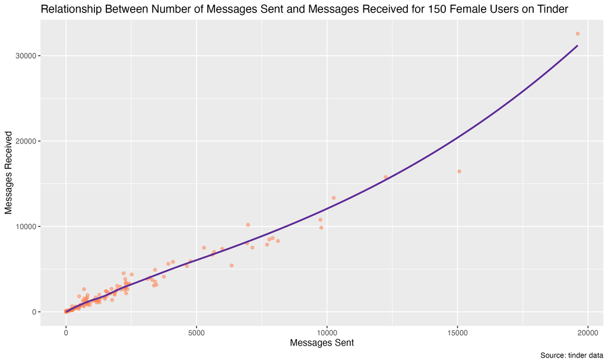

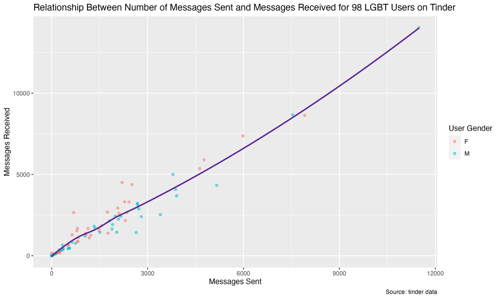

Relationship between Messages Sent and Messages Received LGBT+ Users

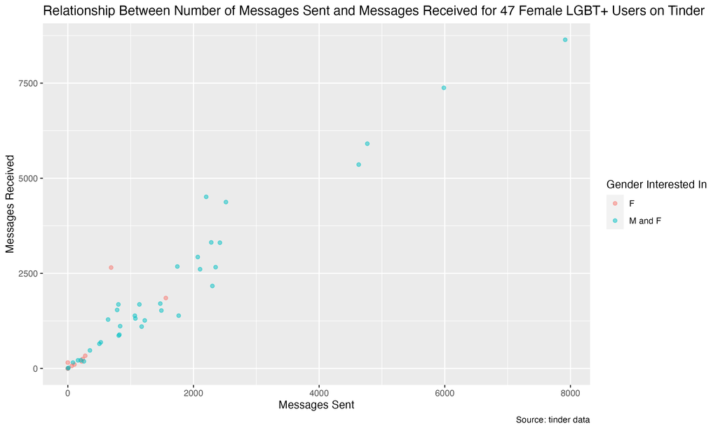

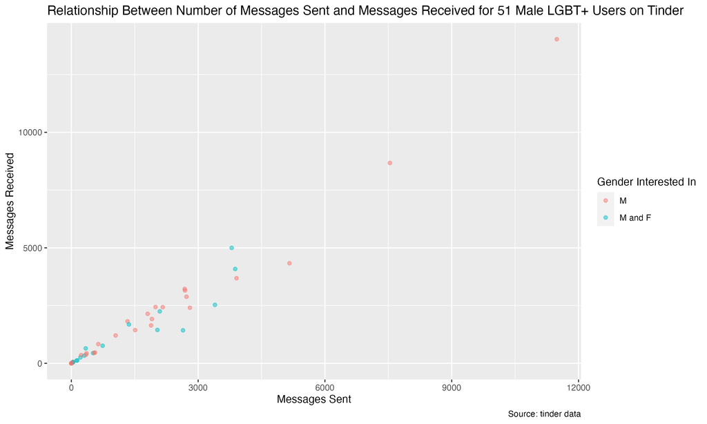